[figure not shown]

# USGS Data Retrieval Demonstration

This updates my older R & Python Notebooks that I've used in the past using a similar USGS package that reads from data from the [USGS National Water Information System (NWIS)](https://waterdata.usgs.gov/nwis), but adapted for Python. This also reflects NWIS's retirement for the [WaterData API](https://api.waterdata.usgs.gov/).

This also shows updates that accommodate the newer USGS API. **The biggest change is the role of the new Key System and the phasing out of the older NWIS system.**

## 2. Libraries

This script uses the following libraries

The Basics...

- [numpy](https://numpy.org/): Python's "go-to" library for math and array/matrix structures
- [pandas](https://pandas.pydata.org/): A fast, powerful, flexible and easy to use open source data analysis and manipulation tool that has structures similar to R's "DataFrame"
- [matplotlib](https://matplotlib.org/stable/): Python's "go-to" Graphics Library.
- [seaborn](https://seaborn.pydata.org/): An extention to Pandas that includes resources for statistical graphical data
- [os](https://docs.python.org/3/library/os.html): this is part of the default installation for Python, but must be invoked as if it's an external library.

And more specialized libraries

- [dataretrieval](https://doi-usgs.github.io/dataretrieval-python/): A Python alternative to the USGS R data retrieval package to obtain USGS and EPA water quality data, streamflow data, and metadata directly from their web services portals.

Note that the water quality data from EPA is no longer updated

Mapping Resources (When running this as a general Python script, you won't want this part.) You can learn how to use these libraries in the [tutorial making WRF Model Domains](https://wjcapehart.github.io/AES_CEE_Python/Jupyter_Notebooks_and_Other_Files/03_Deep_Dives/03_02_Applications/03_02_05_WRF_and_MPAS_Domain_Mapping/WRF_Map_Out_Namelist_WPS.html).

- [CartoPy](https://cartopy.readthedocs.io/stable/): A map projection library. We are specifically requesting the following sub-libraries
  - [CartoPy.crs](https://cartopy.readthedocs.io/stable/reference/crs.html): Cartopy's Coordinate Reference System (CRS) operators. This is the information needed to draw the various projections.
  - [CartoPy.feature](https://cartopy.readthedocs.io/stable/matplotlib/feature_interface.html): Cartopy's Feature Plotting Interface
  - [CartoPy.io.img_tiles](https://cartopy.readthedocs.io/stable/reference/io.html): Access to Mapping Tiles
  - [CartoPy.mpl](https://cartopy.readthedocs.io/stable/reference/matplotlib.html): Cartopy Matplotlib Interface
- [Unidata's MetPy](https://unidata.github.io/MetPy/latest/): Tools for reading, visualizing, and performing calculations with weather data. I'm only using it becasue it has counties and provinces!
- [itables](https://mwouts.github.io/itables/): A Jupyter extension that will allow your tables to be displayed in a manner similar to RStudio, by which you can scroll through them. If you have big or wide tables, this is what you need to explore your data. Be aware that you should comment it out if you export your file into a plain *.py executable.

ITables is having difficulties working with [geopandas.GeoPandasDataframes](https://geopandas.org/en/latest/docs/reference/api/geopandas.GeoDataFrame.html), so I have automatically disabled automated ITables features.

To use ITables on demand you can use the function [itables.show()](https://mwouts.github.io/itables/apps/notebook.html)

Non-Library iPython Resource...

- version_information: Package version documentation to aid in replicability. See its use at the bottom of this notebook.

See its use at the bottom of this notebook. You will need to remove this before saving it as a plain Python "*.py" script.

You may also see me frontload some basic simple functions for common acts in a given script. Below, you will see such an example with a trick to collapse my multi-index columns into a single row.

```python
######################################################
#
# Libraries
#

import numpy              as np
import pandas             as pd
import geopandas          as gp
import matplotlib.pyplot  as plt
import seaborn            as sns
import os                 as os
import datetime           as dt

import dataretrieval.nwis      as nwis
import dataretrieval.waterdata as waterdata

add_Pretty_Map = True

import cartopy.crs          as ccrs
import cartopy.feature      as cfeature
import cartopy.io.img_tiles as cimgt
import cartopy.mpl          as cmpl

from metpy.plots            import USCOUNTIES

import itables

# Set the Indices Display Option to True (it's typically omitted)

itables.options.showIndex = True

# Set the notebook itables model to require active use of itables.show()

itables.init_notebook_mode(all_interactive=False)

#
# Short Functions
#

def flatten_multi_col_index(df):
    '''
    "flattens" the input dataframe's columns from a "multiindex"
    mode to a single row
    '''
    df.columns = ['_'.join(col).strip('_') for col in df.columns.values]
    return df

#
######################################################
```

Institutions can be persnickety about what branding you use. Here is an example of me using the SD Mine's [official colors](https://brand.sdsmt.edu/visual-design/colors/) and [passive-aggressively partially-open-source fonts](https://brand.sdsmt.edu/visual-design/typography/).

If you aren't at SD Mines you can still customize your own Veronica Lake Memorial Malicious Compliance. ([#AskyYourGrandparents](https://tvtropes.org/pmwiki/pmwiki.php/Film/SoProudlyWeHail))

[figure not shown]

```python
#########################################
#
# Colors and South Dakota Mines Communications Policy
#

SD_Mines_CP = True

#
# SDSMT Official Colors
#

SDM_Navy  = "#002554"
SDM_Blue  = "#385E9D"
SDM_Gold  = "#B3A369"
SDM_Green = "#CEDC00"

SDM_Grey4 = "#75787B"
SDM_Grey3 = "#BBBCBC" # good basic grey
SDM_Grey2 = "#D9D9D9"
SDM_Grey1 = "#EDEDED"

#
# Malicious Compliance
#

if SD_Mines_CP:

    # this dictionary contains customized RC parametrers for Matplotlib

    custom_params = {"axes.spines.right" : False, # I like minimal plots
                     "axes.spines.top"   : False, # so I take out the spines
                     "font.sans-serif"   :['Open Sans',   # This shows the cascade
                                           'DejaVu Sans', # of font selection
                                           'Arial'],
                     'text.color'        : SDM_Navy, # and here the colors
                     'xtick.color'       : SDM_Navy,
                     'ytick.color'       : SDM_Navy,
                     'axes.edgecolor'    : SDM_Navy,
                     'axes.labelcolor'   : SDM_Navy,
                     "grid.color"        : "#e8f2ff"}

    sns.set_theme(style = "ticks",
                  rc    = custom_params)
    sns.axes_style()


#
#########################################
```

## 3. A fast summary of the USGS Water APIs

This is being replaced with the more modern WaterData API.

The USGS maintains an extensive dataset collection accessible to the public via its web interfaces. These can be accessed through their "pretty" websites, or by entering a cryptic URL.

However, people who want to forego web clicking and have a programming background may wish to dive directly into the raw data so they can repeatedly pull/analyze it.

The USGS [DataRetrieval](https://doi-usgs.github.io/dataretrieval-python/index.html) package provides resources for accessing multiple USGS data APIs, similar to those developed for NOAA/NWS/NCEI weather and climate data sources.

### 3.1. Map of This Activity

In this exercise, I'll present a typical workflow based on WaterData's predecessor, the NWIS.

Let's consider a scheme to extract daily stream gage stations data from a given [USGS HUC-08 watershed](https://nas.er.usgs.gov/hucs.aspx).

My general flow that I'm evolving with this new Water Data API suite is to...

As most exercises where I spell out a new procedure with Python or R, I will do this in excruciatingly slow motion, deep diving into each step.

### 3.2 But FIRST! Get your API Key.

Get your own API key! I have one below. Use your own. (At some point they will probably revoke mine for breaking the internet.)

Head to the following site:

https://api.waterdata.usgs.gov/signup/

It will want an email. Use your official email address.

Once you register, you will get an email delivered from **noreply@api.data.gov**

To source the code, use the following *with your own key*.

The key below is not a real key. Like, I said, get your own!

This approach will set your "environment variables" with the [os.environment()](https://www.geeksforgeeks.org/python/python-os-environ-object/) command.

Honestly, I am not sure how this works with the new USGS API's python interface. With NCEI and NASA, these are pushed in as login credentials.

```python
######################################################
#
# Pulling Station Information
#

usgs_key = "THIS IS NOT THE KEY YOU ARE LOOKING FOR"

os.environ["API_USGS_PAT"] = usgs_key

#
######################################################
```

## 4. Getting Search Criteria

Let's start here by collating our search criteria. Not all criteria will be used in each step of the query, but let's keep it on one spot.

### 4.1. Hydrologic Unit (Watershed or Basin)

Start by pulling the data for your specific HUC. I recommended [this resource to drill down to your preferred HUC](https://www.arcgis.com/apps/View/index.html?appid=8909697be04f40eaab0ee753547f4807). The watersheds at the various levels of "zoom" will be in purple with the HUC codes in purple Times Roman Font. In this case, I am using the "Level 8" HUC for Rapid Creek, SD: HUC-08 10120110. We'll eventually be targeting [USGS Station 06414000, Rapid Creek at Rapid City, SD](https://waterdata.usgs.gov/monitoring-location/USGS-06414000/#dataTypeId=continuous-00065-0&period=P365D&showFieldMeasurements=true). (This is the gage that is in the Gap across from Office Depot.)

These will be found under the API Search Codes:

- **hydrologic_unit_code** : for us in this activity, "10120110"
- **monitoring_location_id** : "USGS-06414000" for "Rapid Creek at Rapid City, SD"

### 4.2. Observation Information

Here, we want to be more specific and identify the

- Type of Station or [**site_type_code**](https://api.waterdata.usgs.gov/ogcapi/v0/collections/site-types/items) : For us this will be "ST" or Stream Station.
- Period of Time Aggregation **computation_period_identifier** : "Daily"
- Specific Parameter or [**parameter_code**](https://api.waterdata.usgs.gov/ogcapi/v0/collections/parameter-codes/items) : "00060" or Discharge in CFS
- Statistical Method or [**statistic_id**](https://api.waterdata.usgs.gov/ogcapi/v0/collections/statistic-codes/items) : "00003" or Mean over the period

With this we can make the following request list.

```python
######################################################
#
# Station Search Criteria
#

hydrologic_unit_code          = "10120110"      # Rapid Creek HUC
site_type_code                = "ST"            # Stream Stations
computation_period_identifier = "Daily"         # Daily Aggregation
parameter_code                = "00060"         # Discharge in cfs
statistic_id                  = "00003"         # Mean
monitoring_location_id        = "USGS-06414000" # "Rapid Creek at Rapid City, SD"

#
######################################################
```

### 4.3. Retrieving the Station Location and Specific Data Set Information

The new WaterData's monitoring location data can be pulled with dataretrieval.waterdata.get_monitoring_locations

While there are a LOT of variables to tunnel into for station location information, we're only going to use two: the HUC and the Site type.

The output is two-fold. You will get a geopandas.GeoDataFrame and a metadata query that can be put into a web browser.

Since this is a GeoDataFrame, you can also do a quick-and-dirty map plot. (We'll make it prettier later.)

```
Retrieving: monitoring-locations · 1 page · 156 rows · 976/1,000 requests remaining
```

```
Monitoring Locations for HUC10120110
URL: https://api.waterdata.usgs.gov/ogcapi/v0/collections/monitoring-locations/items?site_type_code=ST&hydrologic_unit_code=10120110&skipGeometry=False&limit=50000
```

[figure not shown]

Loading ITables v2.8.1 from the `init_notebook_mode` cell... (need [help](https://mwouts.github.io/itables/troubleshooting.html)?)

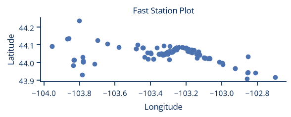

```python
######################################################
#
# Retrieving the Station Location Information
#

df_st_metadata, md_st_metadata =  \
    waterdata.get_monitoring_locations(hydrologic_unit_code = hydrologic_unit_code,
                                       site_type_code       = site_type_code)

print("Monitoring Locations for HUC" + hydrologic_unit_code )

# Display URL

print("URL:",md_st_metadata.url)

# Display URL Table (you need to drop the geometry column or it will break itables)

itables.show(df      = df_st_metadata.drop(columns=["geometry"]),
             caption = "Monitoring Locations for " + hydrologic_unit_code + ", "+ site_type_code)

# Fast Station Location Plot

df_st_metadata.plot()
plt.title("Fast Station Plot")
plt.xlabel("Longitude")
plt.ylabel("Latitude")
plt.show()

#
######################################################
```

As you can see, there are a lot of stations, most are not carrying the variables we want, and a lot may no longer be active. But at least they have human-friendly names with the above query. We will want to dig deeper in the next step, but we will be using the handy "people-friendly names."

This will use the [dataretrieval.waterdata.get_time_series_metadata()](https://doi-usgs.github.io/dataretrieval-python/reference/waterdata.html#dataretrieval.waterdata.get_time_series_metadata)

```
Retrieving: time-series-metadata · 1 page · 32 rows · 976/1,000 requests remaining
```

```
Time Series Discharge Data for HUC10120110
URL: https://api.waterdata.usgs.gov/ogcapi/v0/collections/time-series-metadata/items?parameter_code=00060&statistic_id=00003&hydrologic_unit_code=10120110&skipGeometry=False&limit=50000
```

[figure not shown]

Loading ITables v2.8.1 from the `init_notebook_mode` cell... (need [help](https://mwouts.github.io/itables/troubleshooting.html)?)

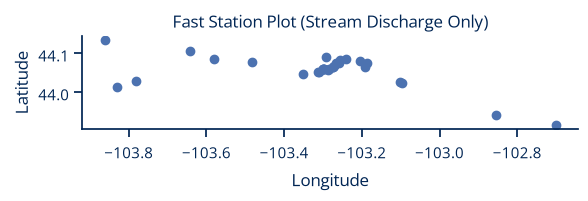

```python
######################################################
#
# Retrieving the Station Time Series Information
#

df_ts_metadata, md_ts_metadata =  \
    waterdata.get_time_series_metadata(hydrologic_unit_code = hydrologic_unit_code,
                                       parameter_code       = parameter_code,
                                       statistic_id         = statistic_id)

print("Time Series Discharge Data for HUC" + hydrologic_unit_code )

# Display URL

print("URL:",md_ts_metadata.url)

# Display URL Table (you need to drop the geometry column or it will break itables)

itables.show(df      = df_ts_metadata.drop(columns=["geometry"]),
             caption = "Time Series Discharge Data for HUC " + hydrologic_unit_code + ", "+ site_type_code)

# Fast Station Location Plot

df_ts_metadata.plot()
plt.title("Fast Station Plot (Stream Discharge Only)")
plt.xlabel("Longitude")
plt.ylabel("Latitude")
plt.show()

#
######################################################
```

```
Active Time Series Discharge Data for HUC10120110
```

[figure not shown]

Loading ITables v2.8.1 from the `init_notebook_mode` cell... (need [help](https://mwouts.github.io/itables/troubleshooting.html)?)

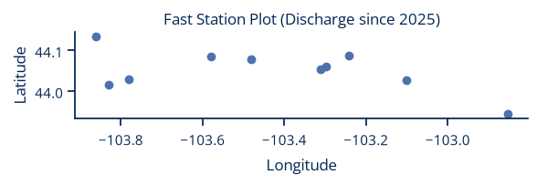

```python
######################################################
#
# Trimming down to only currently-active stations
#

df_ts_metadata = df_ts_metadata[df_ts_metadata["end"].dt.year >= 2025]

print("Active Time Series Discharge Data for HUC" + hydrologic_unit_code )

# Display URL Table (you need to drop the geometry column or it will break itables)

itables.show(df      = df_ts_metadata.drop(columns=["geometry"]),
             caption = "Active Time Series Discharge Data for HUC " + hydrologic_unit_code + ", "+ site_type_code)

# Fast Station Location Plot

df_ts_metadata.plot()
plt.title("Fast Station Plot (Discharge since 2025)")
plt.xlabel("Longitude")
plt.ylabel("Latitude")
plt.show()


#
######################################################
```

### 4.4. Joining or "Merging" our 2 Metadata Files

I find this aspect of the new datasets annoying, but I suspect that separating explicit geographic metadata from the rest of the data is easier on disk space.

But here it IS a good idea for us to merge our thinned-out dataframe with the spatial information locally.

Of the two dataframes, I checked to see which columns are common to both:

```
print(list(set(df_ts_metadata.columns).intersection(df_st_metadata.columns)))
```

The common values are ['geometry', 'hydrologic_unit_code', 'monitoring_location_id', 'state_name'].

So here I am going to do what in "R" is called a "join" and in Pandas is called a merge by columns.

```python
######################################################
#
# Trimming down to only currently-active stations
#

df_metadata = pd.merge(left  = df_st_metadata, # The dominant frame (all rows will be retained)
                       right = df_ts_metadata) # The subordinate frame (all rows not in the dom frame will be discarded)

print("Joined Metadata Table")
itables.show(df = df_metadata.drop(columns=["geometry"]))

#
######################################################
```

```
Joined Metadata Table
```

[figure not shown]

Loading ITables v2.8.1 from the `init_notebook_mode` cell... (need [help](https://mwouts.github.io/itables/troubleshooting.html)?)

And these will be the stations we pull.

But FIRST!

### 4.RabitHole! Making a Nice Station Map.

Let's go back to those fast station plots. They're good for a quick inspection, especially if you already know the lay of the land (or, here, the river) in advance.

If you pay a visit to the ["Rage-Quit 'Splainers" at my Crying Fort](https://wjcapehart.github.io/AES_CEE_Python/03%20Rage-Quit%20Explainers%20and%20Deep%20Dives.html), you will see guidance on how to make nice maps.

The general steps are presented here. This is [mostly basic mapping in Python](https://wjcapehart.github.io/AES_CEE_Python/03%20Rage-Quit%20Explainers%20and%20Deep%20Dives.html#projecting-maps-not-psychological-in-python-and-trolling-flat-earthers).

- Drop a figure/"workstation" object with [matplotlib.pyplot.figure](https://matplotlib.org/stable/api/_as_gen/matplotlib.pyplot.figure.html)
- Create a coordinate reference system with the [cartopy.crs.*](https://scitools.org.uk/cartopy/docs/latest/reference/crs.html) group. I prefer to use Transverse Mercator when I don't have any other requirements and I'm working with small local areas (from there, as a meteorologist for whom angle conformity is a priority, I will scale up to Lambert Conformal Conic).
- Apply that projection to a new subplot element with [matplotlib.figure.Figure.add_subplot()](https://matplotlib.org/stable/api/_as_gen/matplotlib.figure.Figure.add_subplot.html)
- Now for the new steps:
  - Access a tile set for mapping. I typically use either Google Maps or Open Science Maps (OSM) as I am doing here with [cartopy.io.img_tiles.OSM()](https://scitools.org.uk/cartopy/docs/latest/reference/generated/cartopy.io.img_tiles.OSM.html)
  - Order the dropping of that image tile with a given "zoom" level with [cartopy.mpl.geoaxes.GeoAxes.add_image()](https://scitools.org.uk/cartopy/docs/latest/reference/generated/cartopy.mpl.geoaxes.GeoAxes.html#cartopy.mpl.geoaxes.GeoAxes.add_image). You will need to do a little trial and error to get the right "zoom" level.
  - When the map is rendered, the tile source will be downloaded and integrated accordingly based on other arguments in the plot generation (e.g., the extent of the plot.
- From there, we can drop the pandas coordinates with [geopandas.GeoDataFrame](https://geopandas.org/en/stable/docs/reference/geodataframe.html) and close the map with labeling your plot [[matplotlib.axes.Axes.set_title](https://matplotlib.org/stable/api/_as_gen/matplotlib.axes.Axes.set_title.html)] and seal the deal with plot.show().

Here, I am also going to have a little more control over the size of my bounding box for the plot. You can query how large your net extent of your dataframe is by querying the "geometry" element with the [GeoSeries.total_bounds()](https://geopandas.org/en/stable/docs/reference/api/geopandas.GeoSeries.total_bounds.html) and set the extent of your plot accordingly with [cartopy.mpl.geoaxes.GeoAxes.set_extent()](https://scitools.org.uk/cartopy/docs/v0.13/matplotlib/geoaxes.html#cartopy.mpl.geoaxes.GeoAxes.set_extent). Just don't forget to include the projection/transform information!

```
add_Pretty_Map =  True
```

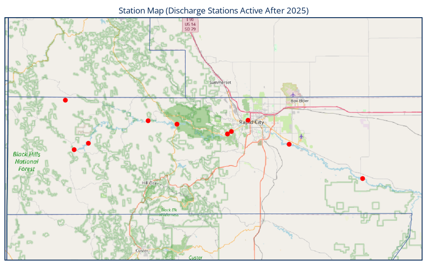

```python
##############################################
#
# Make a map with Google Maps Cartopy API
#

min_lon, min_lat, max_lon, max_lat = df_metadata["geometry"].total_bounds

fig = plt.figure(figsize=(11, 7))

# create a simple localized platform (I like Transverse Mercator customized on my location)

myproj = ccrs.TransverseMercator(central_latitude  = df_metadata["geometry"].get_coordinates().mean()["y"],
                                 central_longitude = df_metadata["geometry"].get_coordinates().mean()["x"])

# add a plot element just one field aka the "Axes"

ax = fig.add_subplot(1,  # nrows
                     1,  # ncols
                     1,  # index of figure you're installing
                     projection = myproj)  # cartopy CRS Projection

print("add_Pretty_Map = ",add_Pretty_Map)

if add_Pretty_Map:


    # Request Map Tiles

    map_tiles = cimgt.OSM(desired_tile_form="RGB")

    # Lay down the map tiles

    ax.add_image(map_tiles, 10)



ax.add_feature(feature    = cfeature.STATES,
               edgecolor  = SDM_Navy,
               facecolor  = 'none')
ax.add_feature(feature    = cfeature.COASTLINE,
               edgecolor  = SDM_Blue,
               facecolor  = 'none')
ax.add_feature(feature    = USCOUNTIES,
               linewidths = 0.5,
               edgecolor  = SDM_Blue,
               facecolor  = 'none')

# set your plot extent

ax.set_extent([min_lon-0.2, max_lon+0.2,
               min_lat-0.2, max_lat+0.2],
              crs=ccrs.PlateCarree())

# Here's your data

df_metadata.plot(ax        =              ax,
                 color     =           "red",
                 transform = ccrs.Geodetic())

# Good People Label their Plots

ax.set_title("Station Map (Discharge Stations Active After 2025)")

# Display and Close Graph

plt.show()

#
##############################################
```

OK, now back to work!

### 4.5 Now Let's Fetch the Actual Data (i.e., the Numbers)

The command here for us is to extract the daily aggregated data [dataretrieval.waterdata.get_daily()](https://doi-usgs.github.io/dataretrieval-python/reference/waterdata.html#dataretrieval.waterdata.get_daily)

We will need to convert the column in the metadata dataframe into a traditional Python list.

Also, to better arrange the data, we can create a simple multi-index dataframe in pandas with [pandas.DataFrame.set_index()](https://pandas.pydata.org/docs/reference/api/pandas.DataFrame.set_index.html)

A warning for those of you who want to work with seaborn for time-series line plots.

While pandas and matplotlib can handle missing data when plotting, leaving gaps where time series are broken, seaborn.lineplot() wipes numpy.NaNs from the internal processing for plots.

```
Retrieving: daily · 5 pages · 228,425 rows · 971/1,000 requests remaining
```

[figure not shown]

Loading ITables v2.8.1 from the `init_notebook_mode` cell... (need [help](https://mwouts.github.io/itables/troubleshooting.html)?)

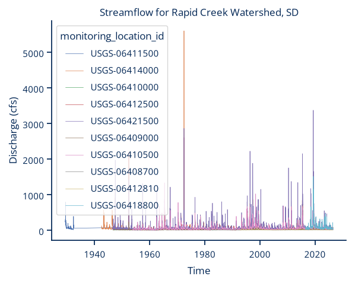

```python
##############################################
#
# Extract Time Series Data (Multiple Stations)
#

df_ts_data, md_ts_data =  \
    waterdata.get_daily(time_series_id = df_metadata["time_series_id"].to_list())

# Get the Time Series for All Stations

df_ts_data.set_index(keys    = ['time', 'monitoring_location_id'],
                     inplace = True)

itables.show(df = df_ts_data.drop(columns=["geometry"]))

# Plot Results

sns.lineplot(data      = df_ts_data,
             x         = "time",
             y         = "value",
             hue       = "monitoring_location_id",
             linewidth = 0.5)

plt.title("Streamflow for Rapid Creek Watershed, SD")
plt.xlabel("Time")
plt.ylabel("Discharge (cfs)")
plt.show()

#
##############################################
```

And we can simply extract the data for a single station using our larger search criteria from above.

(Or given that we've already invested in a download, we can just filter by the "monitoring_location_id")

```
Retrieving: daily · 1 page · 30,694 rows · 969/1,000 requests remaining
```

[figure not shown]

Loading ITables v2.8.1 from the `init_notebook_mode` cell... (need [help](https://mwouts.github.io/itables/troubleshooting.html)?)

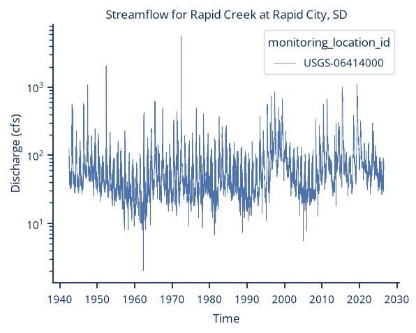

```python
##############################################
#
# Extract Time Series Data (Single Station)
#

df_single_ts_data, md_single_ts_data =  \
    waterdata.get_daily(monitoring_location_id = monitoring_location_id,
                        parameter_code         = parameter_code,
                        statistic_id           = statistic_id)

# Get the Time Series for All Stations

df_single_ts_data.set_index(['time', 'monitoring_location_id'], inplace=True)

itables.show(df = df_single_ts_data.drop(columns=["geometry"]))

#

sns.lineplot(data      = df_single_ts_data,
             x         = "time",
             y         = "value",
             hue       = "monitoring_location_id",
             linewidth = 0.5)

plt.yscale("log")

plt.title("Streamflow for Rapid Creek at Rapid City, SD")
plt.xlabel("Time")
plt.ylabel("Discharge (cfs)")
plt.show()

#
##############################################
```

### 4.6 Cleanup

I do a lot of cleanup once I have my data.

This includes

- Dropping unnecessary columns.
- Renaming cryptic columns. Not hard if you are doing one variable per dataframe for now. Pro tip: Just do one variable at a time; it's not worth the drama of pivoting the data frame.
- Add any extra columns (e.g., Water Year)
- Sometimes I need to deal with Ice Flags (I just set the Discharge to zero and forget that I ever saw [Omen II](https://tvtropes.org/pmwiki/pmwiki.php/Film/DamienOmenII)).
  - Here I am just going to use the quality check flag below and set things to 0 if it contains Ice.
  - At some of these sites, we DO know that we WILL have streamflow beneath the ice and leave them as NaNs.
- For the big one, I am also going to fill up our stuff

Later, I will take extra steps, such as processing water years and other parameters.

#### 4.6.1 Drop, Add, and Rename Columns.

I don't need a lot of the columns here so I'll only retain my station ID, time, and values.

That part is easy: rather than dropping columns, I'm only selecting the columns I am retaining. My station ID and time are now indices, so they aren't columns anymore but identified by rows.

Also, I am using [pandas.DataFrame.rename()](https://pandas.pydata.org/docs/reference/api/pandas.DataFrame.rename.html) to change some names.

```python
##############################################
#
# Drop Un-needed columns (or here, just keep the two I want)
#

df_ts_data        = df_ts_data[       ["value", "qualifier"]]

df_single_ts_data = df_single_ts_data[["value", "qualifier"]]


#
# Change the column names to people-friendly ones.
#

df_ts_data        = df_ts_data.rename(       columns = {"value":"Discharge",
                                                    "qualifier":"Discharge_QC"})

df_single_ts_data = df_single_ts_data.rename(columns = {"value":"Discharge",
                                                    "qualifier":"Discharge_QC"})

#
##############################################
```

#### 4.6.2 Use Flags in one Column to Edit Another.

This isn't always a good idea, since we DO know that anyone who's seen [certain movies](https://tvtropes.org/pmwiki/pmwiki.php/Film/DamienOmenII) knows that people who inadvertently foil the teenage antichrist's plans for agricultural-industry domination fall through the ice and then flow downstream beneath it. Don't question it. It just is.

I don't need many of the columns here, so I'll retain only my station ID, time, and values.

I WILL show the step here for a generic dataframe.

The process leverages the operator, [pandas.Series.str.contains()](https://pandas.pydata.org/docs/reference/api/pandas.Series.str.contains.html) to get a mask of index locations (rows) for which the column test pattern is true,

and the change is made by employing the index mask

```
mask = df['Test_Col'].str.contains(pat   = 'SubString', # Our substring
                                   regex =       False, # assume that this is a plain string
                                   na    =       False) # set cells with missing values to false
    Index_Mask  Changed_Column
         |            |
         v            v
df.loc[mask,  "Change_Column"] = 000
```

### 4.5 Filling Missing Records

It's not uncommon for some datasets to have missing data from a continuous series but archived *without* missing records.

Here since we have a multiindex system, we are first iterate through the stations with [pandas.DataFrame.groupby()](https://pandas.pydata.org/docs/reference/api/pandas.DataFrame.groupby.html).

One inside of a group of stations with [pandas.DataFrame.resample()](https://pandas.pydata.org/docs/reference/api/pandas.DataFrame.resample.html)

Resample will require an aggregation method and here we are using just the "first" method to use the first value of the interval. And if the data is missing that first value is just a "NaN."

I will adding for the water years here.

```python
##############################################
#
# Resample to daily increments with NaNs in the new empty records.
#

df_ts_data_resampled        = df_ts_data.groupby(by     = "monitoring_location_id"). \
                                         resample(rule  =                     '1D',
                                                  level =                   'time'). \
                                         agg(func = 'first')



df_single_ts_data_resampled = df_single_ts_data.groupby(by     = "monitoring_location_id"). \
                                                resample(rule  =                     '1D',
                                                         level =                   'time'). \
                                                agg(func = 'first')




#
##############################################
```

And let's add a water year... (I'm also cutting off our WYs at 2025)

```python
##############################################
#
# Adding a Water Year
#

df_ts_data_resampled['WaterYear']        = np.where(df_ts_data_resampled.index.get_level_values('time').month < 10,
                                                    df_ts_data_resampled.index.get_level_values('time').year,
                                                    df_ts_data_resampled.index.get_level_values('time').year + 1)

df_single_ts_data_resampled['WaterYear'] = np.where(df_single_ts_data_resampled.index.get_level_values('time').month < 10,
                                                    df_single_ts_data_resampled.index.get_level_values('time').year,
                                                    df_single_ts_data_resampled.index.get_level_values('time').year + 1)

#
# Cutting Water Year
#

df_ts_data_resampled        =        df_ts_data_resampled[       df_ts_data_resampled['WaterYear'] <        df_ts_data_resampled['WaterYear'].max()]
df_single_ts_data_resampled = df_single_ts_data_resampled[df_single_ts_data_resampled['WaterYear'] < df_single_ts_data_resampled['WaterYear'].max()]

df_ts_data_resampled        =        df_ts_data_resampled[       df_ts_data_resampled['WaterYear'] >        df_ts_data_resampled['WaterYear'].min()]
df_single_ts_data_resampled = df_single_ts_data_resampled[df_single_ts_data_resampled['WaterYear'] > df_single_ts_data_resampled['WaterYear'].min()]

#
# Display
#

itables.show(df_ts_data_resampled)

#
##############################################
```

[figure not shown]

Loading ITables v2.8.1 from the `init_notebook_mode` cell... (need [help](https://mwouts.github.io/itables/troubleshooting.html)?)

## 5. NOW PLAY! (Let's filter the Rapid City station to make an Annual Max Series (AMS).

Here I am just getting the Annual Max Series (a.k.a., an "AMS" series) for all the observations. I'm also using some diagnostics, such as determining the beginning and end of the water year.

I'm including a plot to graphically inspect the "inventory" of the various stations. I can use this to better prune my empty water years or gaps in my data record.

[figure not shown]

Loading ITables v2.8.1 from the `init_notebook_mode` cell... (need [help](https://mwouts.github.io/itables/troubleshooting.html)?)

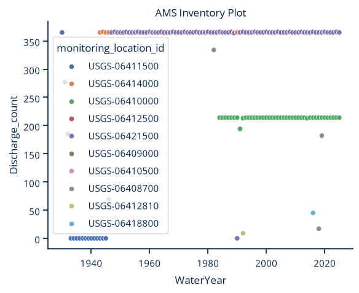

```python
##############################################
#
# Annual Max Series Multi
#

df_ams_resampled = df_ts_data_resampled.reset_index(). \
                                        groupby(by = ["WaterYear",
                                                      "monitoring_location_id"]). \
                                        agg(     {"time":{"min","max"},
                                             "Discharge":{"max","count"}})

df_ams_resampled = flatten_multi_col_index(df_ams_resampled)

itables.show(df_ams_resampled)

#
# Adding diagnostic plot
#


g = sns.scatterplot(data =         df_ams_resampled,
                    x    =              "WaterYear",
                    y    =        "Discharge_count",
                    hue  = "monitoring_location_id")


plt.title("AMS Inventory Plot")
plt.show()

#
##############################################
```

(That one that seems to be consistently only active for part of the year is the Castle Creek stream gage [[USGS-06410000]](https://waterdata.usgs.gov/monitoring-location/USGS-06410000/#dataTypeId=continuous-00065-0&period=P7D&showFieldMeasurements=true) just below Deerfield Dam.)

But with this inspection, you can further trim your data.

I've found it much easier to work with single stations for these kinds of analysis. For multiple stations, that's what big outer loops are for!

Here the structure is similar to above but I can now add a field to show where the madximum storm event is using [pandas.Series.idxmax](https://pandas.pydata.org/docs/reference/api/pandas.Series.idxmax.html)

[figure not shown]

Loading ITables v2.8.1 from the `init_notebook_mode` cell... (need [help](https://mwouts.github.io/itables/troubleshooting.html)?)

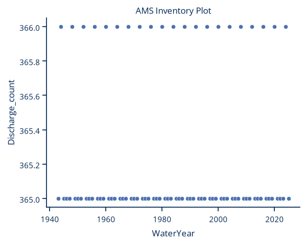

[figure not shown]

Loading ITables v2.8.1 from the `init_notebook_mode` cell... (need [help](https://mwouts.github.io/itables/troubleshooting.html)?)

```python
##############################################
#
# Annual Max Series Single
#

df_ams_single_resampled = df_single_ts_data_resampled.reset_index(). \
                                        groupby(by = "WaterYear").   \
                                        agg(     {"time":{"min","max"},
                                             "Discharge":{"max","count"}})

df_ams_single_resampled = flatten_multi_col_index(df_ams_single_resampled)


itables.show(df_ams_single_resampled)

#
# Adding diagnostic plot
#

sns.scatterplot(data =  df_ams_single_resampled,
                x    =              "WaterYear",
                y    =        "Discharge_count")
plt.title("AMS Inventory Plot")
plt.show()

#
# Identifying my max event dates
#


max_value_date = df_single_ts_data_resampled.reset_index().     \
                                             set_index("time").  \
                                             groupby(by = "WaterYear")['Discharge'].idxmax() #. \

max_value_date.name = "Max Discharge Date"

df_ams_single_resampled["Max Discharge Date"] = max_value_date

itables.show(df_ams_single_resampled)



#
##############################################
```

And "finally" I can now merge now both the orignal single-series data with the AMS data!

And let's close with a classic head-on-pike presentation method.

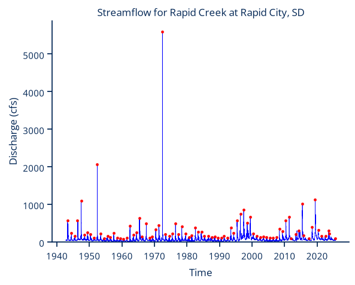

```python
##############################################
#
# Annual Max Series Single
#

sns.lineplot(data      = df_single_ts_data_resampled,
             x         = "time",
             y         = "Discharge",
             color     = "blue",
             linewidth = 0.5)

# Heads on Pikes are fun.

sns.scatterplot(data       = df_ams_single_resampled,
                x          = "Max Discharge Date",
                y          = "Discharge_max",
                color      = "red",
                edgecolors = None, # a marker can have an outline color (default is often white)
                s          = 10,   # makersize (pointsize)
                zorder     = 99)   # bigger zorders bring it to the front


plt.title("Streamflow for Rapid Creek at Rapid City, SD")
plt.xlabel("Time")
plt.ylabel("Discharge (cfs)")
plt.ylim(bottom=0)
plt.show()


#
##############################################
```

## 6. Version Information

*Version Information* is a package developed by J.R. Johansson and operates as what the iPython/Jupyter Environments calls ["Magic Line" commands](https://jakevdp.github.io/PythonDataScienceHandbook/01.03-magic-commands.html) which are invoked by a "%." This one is convenient since it displays detailed information on the versions of Python, Jupyter, and any other denoted packages (but for those, you DO need to delete them since this is running "outside" of your notebook program.

The output will be in JSON format in the Jupyter Lab Notebook, but it will be a professional-looking table when rendered as an HTML file.

```python
################################################################
#
# Loading Version Information
#

%load_ext version_information
%version_information numpy, matplotlib, pandas, geopandas, dataretrieval, cartopy, itables, version_information

#
################################################################
```

| Software | Version |
| --- | --- |
| Python | 3.12.12 64bit [Clang 19.1.7 ] |
| IPython | 9.14.1 |
| OS | macOS 26.5.2 arm64 arm 64bit |
| numpy | 2.4.6 |
| matplotlib | 3.11.0 |
| pandas | 3.0.3 |
| geopandas | 1.1.3 |
| dataretrieval | 0.0.0 |
| cartopy | 0.25.0 |
| itables | 2.8.1 |
| version_information | 1.0.4 |
| Tue Jul 14 14:02:01 2026 MDT |  |